# Growth curve analysis using the Tecan 96-well plate reader - Knockout Strains May 29 2026

Tanishka Joshi

Last compiled on 05 June, 2026

- The .csv containing the OD data can be found [here](https://github.com/GreshamLab/vignettes/blob/master/David_Ina_OD_mCit_YPD_Glnlim_11012022-001.csv)
- The .csv containing the samplesheet information can be found [here](https://github.com/GreshamLab/vignettes/blob/master/samplesheet.csv)

# Growth curves requirements

We also measured GFP at each time point, but these data were not included in the analysis.

Before running the analysis we formatted data as follows:

- OD data from the Tecan in a csv with each well’s data in a column, the first row contained the well names, and the first column is time stamps in seconds
- A sample sheet, with the *four* required columns: **Well**, **Sample**, **Bio_rep**, **Tech_rep**
  - The Well column did not have 0s in the well names (i.e. A1, not A01)
  - An additional column - **Species** - after Tech_rep which will be output as well metadata with the growth curve information 9an abritrary number of columns can be added)
  - For blank wells, we put ‘B’ in the Sample column of the sample sheet
  - For blank wells, we put ‘NA’ for all other column values

# Set up the file paths and names

This step defines the files that will be read in, the output files, the number of measurements made during the experiment and the well in which the blank(s) is located.

```r
# Path to directory with csv with OD data and sample sheet - put the last / after
filepath = 'C:/Users/tanis/Gresham Lab/summerIntensive2026/data/'
# sample sheet file name
s_sheet = 'samplesheet.csv.csv'
# data csv
data_file = 'ODdata.csv.csv'
# specific the number of cycles
cycles = 283
# output csv name
out = 'output.csv'
```

# Load libraries

We use `growthcurver` for analysis and `tidyverse` for data manipulation and plotting.

```r
knitr::opts_chunk$set(fig.height=6, fig.width=5,
                      cache=TRUE, autodep = TRUE, cache.path = 'facet-rep-labels/')
library(tidyverse)
library(growthcurver)
setwd(filepath)
theme_set(theme_minimal())
```

# Read in sample sheet and data

In this step we fix the name of the time column and convert time from seconds to hours. We read in the samplesheet and OD measurements and confirm that they are organized correctly.

```r
samplesheet = read_csv(paste0(filepath, s_sheet))
knitr::kable(samplesheet)
```

| Well | Sample | Bio_rep | Tech_rep | Species |
| --- | --- | --- | --- | --- |
| A1 | Scerevisiae_YPD | 1 | 1 | Saccharomyces cerevisae |
| A2 | Scerevisiae_YPD | 2 | 1 | Saccharomyces cerevisae |
| A3 | Scerevisiae_YPD | 3 | 1 | Saccharomyces cerevisae |
| A4 | Scerevisiae_YPD | 1 | 1 | Saccharomyces cerevisae |
| A5 | Scerevisiae_YPD | 2 | 1 | Saccharomyces cerevisae |
| A6 | Scerevisiae_YPD | 3 | 1 | Saccharomyces cerevisae |
| A7 | Scerevisiae_YPD | 4 | 1 | Saccharomyces cerevisae |
| A8 | Scerevisiae_YPD | 1 | 1 | Saccharomyces cerevisae |
| A9 | Scerevisiae_YPD | 2 | 1 | Saccharomyces cerevisae |
| A10 | Scerevisiae_YPD | 3 | 1 | Saccharomyces cerevisae |
| A11 | Scerevisiae_YPD | 4 | 1 | Saccharomyces cerevisae |
| A12 | Scerevisiae_YPD | 1 | 1 | Saccharomyces cerevisae |
| B1 | Scerevisiae_YPD | 1 | 2 | Saccharomyces cerevisae |
| B2 | Scerevisiae_YPD | 2 | 2 | Saccharomyces cerevisae |
| B3 | Scerevisiae_YPD | 3 | 2 | Saccharomyces cerevisae |
| B4 | Scerevisiae_YPD | 1 | 2 | Saccharomyces cerevisae |
| B5 | Scerevisiae_YPD | 2 | 2 | Saccharomyces cerevisae |
| B6 | Scerevisiae_YPD | 3 | 2 | Saccharomyces cerevisae |
| B7 | Scerevisiae_YPD | 4 | 2 | Saccharomyces cerevisae |
| B8 | Scerevisiae_YPD | 1 | 2 | Saccharomyces cerevisae |
| B9 | Scerevisiae_YPD | 2 | 2 | Saccharomyces cerevisae |
| B10 | Scerevisiae_YPD | 3 | 2 | Saccharomyces cerevisae |
| B11 | Scerevisiae_YPD | 4 | 2 | Saccharomyces cerevisae |
| B12 | Scerevisiae_YPD | 2 | 1 | Saccharomyces cerevisae |
| C1 | Scerevisiae_YPD | 1 | 3 | Saccharomyces cerevisae |
| C2 | Scerevisiae_YPD | 2 | 3 | Saccharomyces cerevisae |
| C3 | Scerevisiae_YPD | 3 | 3 | Saccharomyces cerevisae |
| C4 | Scerevisiae_YPD | 1 | 3 | Saccharomyces cerevisae |
| C5 | Scerevisiae_YPD | 2 | 3 | Saccharomyces cerevisae |
| C6 | Scerevisiae_YPD | 3 | 3 | Saccharomyces cerevisae |

[output cut: 66 more lines]

```r
#remove s from time and convert to numeric, divide by 60 2x to go from seconds to hours
data_od = read_csv(paste0(filepath,data_file),
                   skip = 0, n_max = cycles)
```

```
## ──────────────────────────────────────────────────────── Delimiter: "," dbl
## (97): ...1, A1, A2, A3, A4, A5, A6, A7, A8, A9, A10, A11, A12, B1, B2, B...
```

```r
colnames(data_od)[1] <- "time"
data_od$time <- as.numeric(str_remove(data_od$time,"s"))/60/60

knitr::kable(data_od)
```

| time | A1 | A2 | A3 | A4 | A5 | A6 | A7 | A8 | A9 | A10 | A11 | A12 | B1 | B2 | B3 | B4 | B5 | B6 | B7 | B8 | B9 | B10 | B11 | B12 | C1 | C2 | C3 | C4 | C5 | … |
| --- | --- | --- | --- | --- | --- | --- | --- | --- | --- | --- | --- | --- | --- | --- | --- | --- | --- | --- | --- | --- | --- | --- | --- | --- | --- | --- | --- | --- | --- | --- |
| 0.0000000 | 0.1350 | 0.1534 | 0.1405 | 0.1233 | 0.1295 | 0.1230 | 0.1230 | 0.1197 | 0.1154 | 0.1328 | 0.1224 | 0.1201 | 0.1457 | 0.1772 | 0.1677 | 0.1325 | 0.1340 | 0.1270 | 0.1218 | 0.1199 | 0.1245 | 0.1226 | 0.1238 | 0.1257 | 0.1522 | 0.1706 | 0.1641 | 0.1357 | 0.1370 | … |
| 0.0833408 | 0.1362 | 0.1516 | 0.1476 | 0.1235 | 0.1292 | 0.1233 | 0.1225 | 0.1528 | 0.1147 | 0.1310 | 0.1227 | 0.1216 | 0.1647 | 0.1497 | 0.1540 | 0.1222 | 0.1212 | 0.1247 | 0.1218 | 0.1195 | 0.1245 | 0.1216 | 0.1226 | 0.1225 | 0.1553 | 0.1551 | 0.1496 | 0.1234 | 0.1230 | … |
| 0.1666817 | 0.1352 | 0.1549 | 0.1517 | 0.1231 | 0.1294 | 0.1232 | 0.1226 | 0.1556 | 0.1147 | 0.1307 | 0.1218 | 0.1210 | 0.1633 | 0.1528 | 0.1536 | 0.1226 | 0.1219 | 0.1243 | 0.1219 | 0.1200 | 0.1239 | 0.1213 | 0.1234 | 0.1221 | 0.1528 | 0.1573 | 0.1510 | 0.1239 | 0.1229 | … |
| 0.2500183 | 0.1348 | 0.1529 | 0.1509 | 0.1225 | 0.1298 | 0.1225 | 0.1229 | 0.1548 | 0.1148 | 0.1307 | 0.1225 | 0.1209 | 0.1643 | 0.1544 | 0.1548 | 0.1227 | 0.1219 | 0.1244 | 0.1228 | 0.1201 | 0.1245 | 0.1217 | 0.1241 | 0.1232 | 0.1523 | 0.1595 | 0.1509 | 0.1244 | 0.1230 | … |
| 0.3333589 | 0.1350 | 0.1529 | 0.1512 | 0.1227 | 0.1303 | 0.1232 | 0.1230 | 0.1571 | 0.1144 | 0.1304 | 0.1227 | 0.1212 | 0.1665 | 0.1558 | 0.1574 | 0.1225 | 0.1221 | 0.1250 | 0.1228 | 0.1207 | 0.1247 | 0.1215 | 0.1242 | 0.1222 | 0.1534 | 0.1586 | 0.1523 | 0.1236 | 0.1231 | … |
| 0.4166964 | 0.1351 | 0.1523 | 0.1503 | 0.1221 | 0.1305 | 0.1233 | 0.1232 | 0.1543 | 0.1141 | 0.1308 | 0.1235 | 0.1214 | 0.1692 | 0.1559 | 0.1609 | 0.1228 | 0.1229 | 0.1268 | 0.1238 | 0.1221 | 0.1259 | 0.1229 | 0.1252 | 0.1210 | 0.1524 | 0.1590 | 0.1515 | 0.1231 | 0.1226 | … |
| 0.5000364 | 0.1347 | 0.1531 | 0.1515 | 0.1227 | 0.1311 | 0.1240 | 0.1236 | 0.1493 | 0.1146 | 0.1306 | 0.1235 | 0.1219 | 0.1692 | 0.1572 | 0.1588 | 0.1233 | 0.1226 | 0.1264 | 0.1235 | 0.1221 | 0.1250 | 0.1222 | 0.1257 | 0.1207 | 0.1531 | 0.1577 | 0.1529 | 0.1238 | 0.1231 | … |
| 0.5833736 | 0.1348 | 0.1544 | 0.1526 | 0.1230 | 0.1316 | 0.1237 | 0.1239 | 0.1481 | 0.1141 | 0.1309 | 0.1237 | 0.1219 | 0.1698 | 0.1597 | 0.1600 | 0.1233 | 0.1233 | 0.1271 | 0.1237 | 0.1222 | 0.1254 | 0.1226 | 0.1263 | 0.1199 | 0.1553 | 0.1580 | 0.1537 | 0.1239 | 0.1233 | … |
| 0.6667117 | 0.1346 | 0.1551 | 0.1529 | 0.1237 | 0.1328 | 0.1240 | 0.1243 | 0.1419 | 0.1147 | 0.1310 | 0.1244 | 0.1219 | 0.1713 | 0.1593 | 0.1619 | 0.1238 | 0.1238 | 0.1276 | 0.1239 | 0.1224 | 0.1254 | 0.1230 | 0.1264 | 0.1193 | 0.1552 | 0.1587 | 0.1540 | 0.1243 | 0.1241 | … |
| 0.7500483 | 0.1349 | 0.1567 | 0.1532 | 0.1237 | 0.1330 | 0.1241 | 0.1242 | 0.1456 | 0.1144 | 0.1307 | 0.1247 | 0.1216 | 0.1723 | 0.1607 | 0.1634 | 0.1242 | 0.1243 | 0.1285 | 0.1242 | 0.1233 | 0.1261 | 0.1237 | 0.1277 | 0.1193 | 0.1560 | 0.1633 | 0.1538 | 0.1242 | 0.1236 | … |
| 0.8333878 | 0.1348 | 0.1561 | 0.1550 | 0.1240 | 0.1346 | 0.1246 | 0.1246 | 0.1442 | 0.1145 | 0.1310 | 0.1248 | 0.1217 | 0.1734 | 0.1609 | 0.1626 | 0.1243 | 0.1243 | 0.1284 | 0.1252 | 0.1232 | 0.1256 | 0.1236 | 0.1283 | 0.1191 | 0.1561 | 0.1639 | 0.1556 | 0.1243 | 0.1241 | … |
| 0.9167275 | 0.1354 | 0.1576 | 0.1549 | 0.1236 | 0.1352 | 0.1252 | 0.1245 | 0.1409 | 0.1142 | 0.1307 | 0.1253 | 0.1222 | 0.1762 | 0.1646 | 0.1675 | 0.1256 | 0.1257 | 0.1301 | 0.1257 | 0.1244 | 0.1267 | 0.1245 | 0.1289 | 0.1187 | 0.1574 | 0.1623 | 0.1559 | 0.1242 | 0.1240 | … |
| 1.0000658 | 0.1355 | 0.1591 | 0.1575 | 0.1249 | 0.1372 | 0.1257 | 0.1249 | 0.1388 | 0.1143 | 0.1311 | 0.1258 | 0.1218 | 0.1751 | 0.1641 | 0.1658 | 0.1252 | 0.1257 | 0.1290 | 0.1249 | 0.1241 | 0.1252 | 0.1238 | 0.1290 | 0.1185 | 0.1575 | 0.1652 | 0.1581 | 0.1249 | 0.1250 | … |
| 1.0834064 | 0.1354 | 0.1599 | 0.1577 | 0.1245 | 0.1384 | 0.1260 | 0.1251 | 0.1439 | 0.1144 | 0.1313 | 0.1262 | 0.1218 | 0.1776 | 0.1654 | 0.1660 | 0.1256 | 0.1263 | 0.1303 | 0.1256 | 0.1248 | 0.1258 | 0.1241 | 0.1298 | 0.1188 | 0.1578 | 0.1658 | 0.1588 | 0.1253 | 0.1250 | … |
| 1.1667439 | 0.1362 | 0.1607 | 0.1590 | 0.1251 | 0.1397 | 0.1265 | 0.1254 | 0.1428 | 0.1146 | 0.1311 | 0.1270 | 0.1223 | 0.1797 | 0.1669 | 0.1694 | 0.1261 | 0.1274 | 0.1306 | 0.1259 | 0.1252 | 0.1261 | 0.1248 | 0.1311 | 0.1191 | 0.1606 | 0.1666 | 0.1606 | 0.1254 | 0.1255 | … |
| 1.2500794 | 0.1366 | 0.1618 | 0.1597 | 0.1252 | 0.1415 | 0.1266 | 0.1254 | 0.1462 | 0.1147 | 0.1316 | 0.1278 | 0.1228 | 0.1813 | 0.1688 | 0.1717 | 0.1270 | 0.1281 | 0.1319 | 0.1268 | 0.1265 | 0.1260 | 0.1252 | 0.1326 | 0.1191 | 0.1613 | 0.1675 | 0.1615 | 0.1256 | 0.1260 | … |
| 1.3334150 | 0.1364 | 0.1644 | 0.1625 | 0.1266 | 0.1432 | 0.1275 | 0.1262 | 0.1446 | 0.1147 | 0.1319 | 0.1286 | 0.1229 | 0.1819 | 0.1697 | 0.1704 | 0.1273 | 0.1285 | 0.1315 | 0.1263 | 0.1256 | 0.1259 | 0.1252 | 0.1324 | 0.1188 | 0.1637 | 0.1706 | 0.1638 | 0.1264 | 0.1263 | … |
| 1.4167556 | 0.1368 | 0.1646 | 0.1627 | 0.1272 | 0.1447 | 0.1279 | 0.1263 | 0.1462 | 0.1148 | 0.1318 | 0.1292 | 0.1228 | 0.1841 | 0.1712 | 0.1728 | 0.1279 | 0.1299 | 0.1324 | 0.1275 | 0.1265 | 0.1265 | 0.1259 | 0.1337 | 0.1194 | 0.1629 | 0.1710 | 0.1648 | 0.1266 | 0.1273 | … |
| 1.5000928 | 0.1376 | 0.1669 | 0.1650 | 0.1290 | 0.1466 | 0.1286 | 0.1266 | 0.1441 | 0.1147 | 0.1320 | 0.1307 | 0.1227 | 0.1851 | 0.1726 | 0.1736 | 0.1283 | 0.1308 | 0.1330 | 0.1269 | 0.1268 | 0.1260 | 0.1258 | 0.1347 | 0.1189 | 0.1644 | 0.1728 | 0.1667 | 0.1271 | 0.1278 | … |
| 1.5834317 | 0.1380 | 0.1685 | 0.1669 | 0.1307 | 0.1486 | 0.1294 | 0.1270 | 0.1488 | 0.1147 | 0.1325 | 0.1312 | 0.1233 | 0.1871 | 0.1748 | 0.1755 | 0.1285 | 0.1324 | 0.1335 | 0.1276 | 0.1279 | 0.1261 | 0.1259 | 0.1357 | 0.1194 | 0.1661 | 0.1736 | 0.1683 | 0.1273 | 0.1287 | … |
| 1.6667686 | 0.1388 | 0.1693 | 0.1679 | 0.1321 | 0.1513 | 0.1299 | 0.1273 | 0.1456 | 0.1149 | 0.1328 | 0.1325 | 0.1232 | 0.1883 | 0.1753 | 0.1767 | 0.1291 | 0.1332 | 0.1343 | 0.1279 | 0.1275 | 0.1262 | 0.1265 | 0.1367 | 0.1194 | 0.1660 | 0.1747 | 0.1695 | 0.1280 | 0.1294 | … |
| 1.7501094 | 0.1389 | 0.1711 | 0.1701 | 0.1327 | 0.1540 | 0.1312 | 0.1280 | 0.1477 | 0.1151 | 0.1328 | 0.1338 | 0.1239 | 0.1900 | 0.1769 | 0.1791 | 0.1304 | 0.1348 | 0.1349 | 0.1284 | 0.1279 | 0.1259 | 0.1274 | 0.1377 | 0.1193 | 0.1673 | 0.1772 | 0.1729 | 0.1294 | 0.1310 | … |
| 1.8334489 | 0.1399 | 0.1735 | 0.1717 | 0.1335 | 0.1569 | 0.1321 | 0.1281 | 0.1458 | 0.1150 | 0.1331 | 0.1350 | 0.1226 | 0.1917 | 0.1787 | 0.1802 | 0.1309 | 0.1365 | 0.1362 | 0.1289 | 0.1283 | 0.1260 | 0.1274 | 0.1394 | 0.1194 | 0.1697 | 0.1788 | 0.1741 | 0.1296 | 0.1317 | … |
| 1.9167861 | 0.1406 | 0.1759 | 0.1733 | 0.1333 | 0.1598 | 0.1327 | 0.1285 | 0.1480 | 0.1153 | 0.1333 | 0.1366 | 0.1230 | 0.1943 | 0.1818 | 0.1835 | 0.1320 | 0.1385 | 0.1373 | 0.1294 | 0.1299 | 0.1266 | 0.1287 | 0.1407 | 0.1195 | 0.1704 | 0.1798 | 0.1752 | 0.1302 | 0.1325 | … |
| 2.0001242 | 0.1413 | 0.1782 | 0.1748 | 0.1342 | 0.1619 | 0.1333 | 0.1288 | 0.1471 | 0.1151 | 0.1332 | 0.1374 | 0.1230 | 0.1978 | 0.1845 | 0.1862 | 0.1336 | 0.1406 | 0.1395 | 0.1300 | 0.1310 | 0.1282 | 0.1292 | 0.1432 | 0.1196 | 0.1715 | 0.1824 | 0.1762 | 0.1301 | 0.1334 | … |
| 2.0834611 | 0.1421 | 0.1796 | 0.1772 | 0.1360 | 0.1660 | 0.1349 | 0.1297 | 0.1484 | 0.1152 | 0.1338 | 0.1386 | 0.1234 | 0.1978 | 0.1850 | 0.1863 | 0.1333 | 0.1421 | 0.1391 | 0.1302 | 0.1303 | 0.1263 | 0.1287 | 0.1431 | 0.1196 | 0.1746 | 0.1861 | 0.1795 | 0.1318 | 0.1353 | … |
| 2.1668011 | 0.1430 | 0.1813 | 0.1787 | 0.1361 | 0.1694 | 0.1358 | 0.1302 | 0.1511 | 0.1154 | 0.1343 | 0.1404 | 0.1234 | 0.2009 | 0.1872 | 0.1892 | 0.1349 | 0.1445 | 0.1408 | 0.1309 | 0.1315 | 0.1274 | 0.1296 | 0.1453 | 0.1197 | 0.1761 | 0.1876 | 0.1810 | 0.1321 | 0.1368 | … |
| 2.2501406 | 0.1439 | 0.1839 | 0.1803 | 0.1367 | 0.1729 | 0.1372 | 0.1306 | 0.1530 | 0.1154 | 0.1344 | 0.1422 | 0.1239 | 0.2031 | 0.1905 | 0.1905 | 0.1361 | 0.1469 | 0.1421 | 0.1316 | 0.1323 | 0.1272 | 0.1299 | 0.1472 | 0.1195 | 0.1783 | 0.1896 | 0.1831 | 0.1331 | 0.1383 | … |
| 2.3334811 | 0.1453 | 0.1860 | 0.1829 | 0.1376 | 0.1765 | 0.1382 | 0.1313 | 0.1494 | 0.1156 | 0.1351 | 0.1436 | 0.1241 | 0.2054 | 0.1920 | 0.1935 | 0.1373 | 0.1498 | 0.1436 | 0.1325 | 0.1331 | 0.1274 | 0.1308 | 0.1487 | 0.1201 | 0.1803 | 0.1919 | 0.1848 | 0.1337 | 0.1399 | … |
| 2.4168192 | 0.1466 | 0.1885 | 0.1857 | 0.1390 | 0.1813 | 0.1401 | 0.1322 | 0.1480 | 0.1159 | 0.1354 | 0.1452 | 0.1245 | 0.2069 | 0.1938 | 0.1939 | 0.1381 | 0.1519 | 0.1445 | 0.1328 | 0.1333 | 0.1270 | 0.1311 | 0.1501 | 0.1203 | 0.1827 | 0.1950 | 0.1876 | 0.1356 | 0.1426 | … |

[output cut: 253 more lines]

# Plot the OD for all wells

## Arranged by biological replicate

Here we visualize each biological replicate. This allows us to assess the agreement between technical and biological replicates.

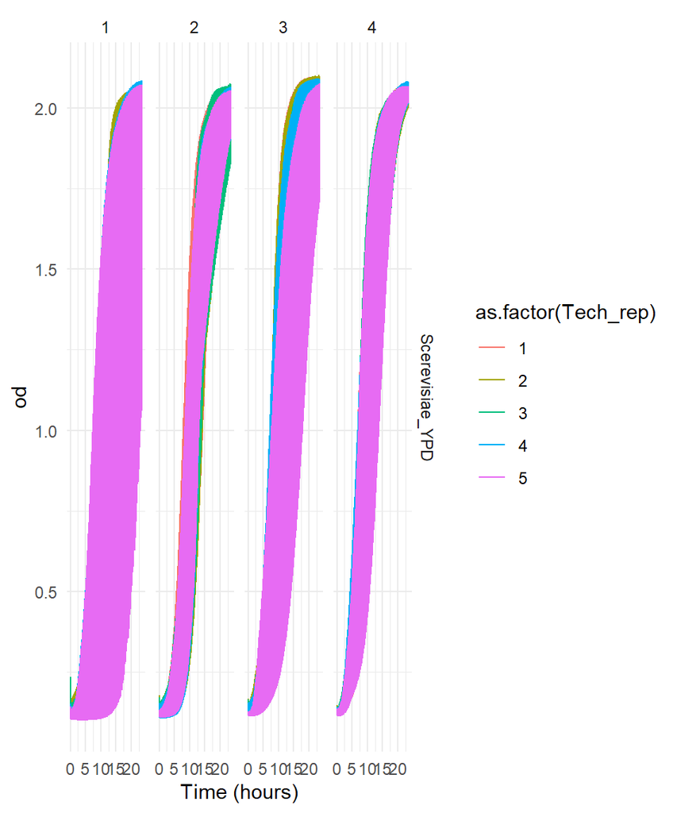

```r
data_od_for_plot <- data_od %>%
  pivot_longer(cols = -time, names_to = "well", values_to = "od") %>%
  left_join(samplesheet, by = c("well" = "Well")) %>%
  unite(Sample_Well, well, Sample, sep = " ", remove = FALSE)

# check wells with samples
ggplot(data_od_for_plot %>% filter(Sample != "B"), aes(time, od, color = as.factor(Tech_rep))) +
  geom_line() +
  facet_grid(Sample~Bio_rep) +
  xlab("Time (hours)")
```

## Check blank wells

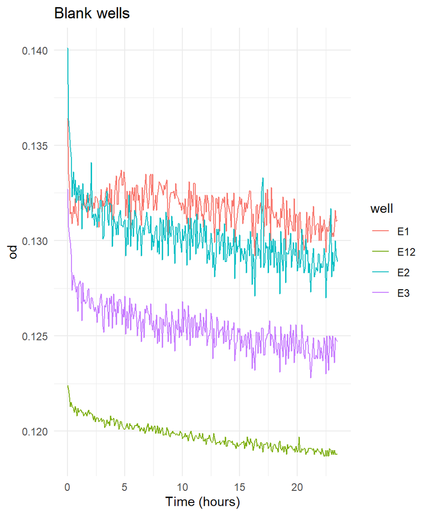

```r
ggplot(data_od_for_plot %>% filter(Sample == "B"), aes(time, od, color = well)) +
    geom_line() +
    #facet_grid(Sample~Bio_rep) +
    xlab("Time (hours)") +
    ggtitle("Blank wells")
```

## Individual Growth Profiles

We plot the entire dataset arrayed in 96 well format it appears on the Tecan for visual inspection. This allows us to easily identify any wells that should be excluded.

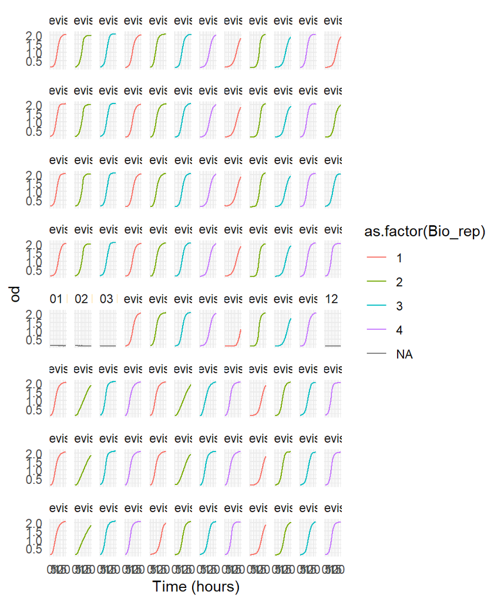

```r
data_od_for_plot %>%
  mutate(Sample_Well = str_replace(Sample_Well, "(?<![0-9])([0-9])(?![0-9])", "0\\1")) %>%
  ggplot(aes(time, od, color = as.factor(Bio_rep))) +
  geom_line() +
  facet_wrap(~Sample_Well, ncol=12) +
  xlab("Time (hours)")
```

# Remove outliers

```r
# wells to remove
outlier_wells = c()

#remove outliers
#for(i in length(outlier_wells)) {
  #data_od = data_od %>%
    #select(!-!as.name(outlier_wells[i]))
#}
```

# Using Growthcurver to fit curve data to logistic equation

```r
#knitr::include_graphics('logistic_eqn.png')
```

- r is growth rate (units: hr^-1)
- k is carrying capacity (units: OD)
- N_0 is starting population size (units: OD)

From this equation several quantities are computed including:

- t_gen, the fastest possible generation time (units: hr)
- t_mid is the time to half maximal k (units: hr)
- sigma is a measure of the goodnesss of fit of the parameters
- The area under the curve (AUC) for each sample, which integrates information from the logistic parameters (k, r, and N0)

```r
gc_out <- SummarizeGrowthByPlate(data_od,
                                 plot_fit = FALSE) %>%
  left_join(samplesheet, by = c("sample" = "Well")) %>%
  rename(well = sample, sample = Sample)

knitr::kable(gc_out)
```

| well | k | n0 | r | t_mid | t_gen | auc_l | auc_e | sigma | note | sample | Bio_rep | Tech_rep | Species |
| --- | --- | --- | --- | --- | --- | --- | --- | --- | --- | --- | --- | --- | --- |
| A1 | 1.896530 | 0.0075910 | 0.5104761 | 10.8071801 | 1.3578447 | 24.0657268 | 23.9806838 | 0.0136292 |  | Scerevisiae_YPD | 1 | 1 | Saccharomyces cerevisae |
| A2 | 1.851154 | 0.0075144 | 0.5607023 | 9.8138991 | 1.2362124 | 25.3257388 | 25.4209513 | 0.0310152 |  | Scerevisiae_YPD | 2 | 1 | Saccharomyces cerevisae |
| A3 | 1.947235 | 0.0120032 | 0.5160438 | 9.8495769 | 1.3431945 | 26.5632342 | 26.5800477 | 0.0105995 |  | Scerevisiae_YPD | 3 | 1 | Saccharomyces cerevisae |
| A4 | 1.869721 | 0.0109130 | 0.4639012 | 11.0750684 | 1.4941698 | 23.2227669 | 23.1359403 | 0.0164115 |  | Scerevisiae_YPD | 1 | 1 | Saccharomyces cerevisae |
| A5 | 1.912080 | 0.0193816 | 0.5516349 | 8.3051986 | 1.2565325 | 29.0217976 | 28.9429208 | 0.0145088 |  | Scerevisiae_YPD | 2 | 1 | Saccharomyces cerevisae |
| A6 | 1.911123 | 0.0094291 | 0.5075263 | 10.4560079 | 1.3657364 | 24.9177077 | 24.8440757 | 0.0124436 |  | Scerevisiae_YPD | 3 | 1 | Saccharomyces cerevisae |
| A7 | 1.915205 | 0.0064113 | 0.4068853 | 13.9994441 | 1.7035444 | 18.2799066 | 18.2692658 | 0.0047611 |  | Scerevisiae_YPD | 4 | 1 | Saccharomyces cerevisae |
| A8 | 2.021720 | 0.0092338 | 0.3050216 | 17.6520435 | 2.2724524 | 12.8243129 | 12.9313339 | 0.0125295 |  | Scerevisiae_YPD | 1 | 1 | Saccharomyces cerevisae |
| A9 | 1.921284 | 0.0001712 | 0.6809253 | 13.6957087 | 1.0179490 | 18.8427861 | 18.9379688 | 0.0230252 |  | Scerevisiae_YPD | 2 | 1 | Saccharomyces cerevisae |
| A10 | 1.863178 | 0.0039188 | 0.3851882 | 15.9977588 | 1.7995026 | 14.2319428 | 14.2371568 | 0.0046135 |  | Scerevisiae_YPD | 3 | 1 | Saccharomyces cerevisae |
| A11 | 1.922409 | 0.0089753 | 0.5362218 | 9.9999166 | 1.2926502 | 25.9411326 | 25.9072080 | 0.0044030 |  | Scerevisiae_YPD | 4 | 1 | Saccharomyces cerevisae |
| A12 | 1.925217 | 0.0025047 | 0.3915644 | 16.9661287 | 1.7701996 | 12.9418526 | 12.9806228 | 0.0063007 |  | Scerevisiae_YPD | 1 | 1 | Saccharomyces cerevisae |
| B1 | 1.921737 | 0.0147359 | 0.5339270 | 9.1079875 | 1.2982059 | 27.6342620 | 27.6743580 | 0.0124534 |  | Scerevisiae_YPD | 1 | 2 | Saccharomyces cerevisae |
| B2 | 1.880530 | 0.0089982 | 0.5377714 | 9.9252071 | 1.2889254 | 25.5159886 | 25.6298216 | 0.0379802 |  | Scerevisiae_YPD | 2 | 2 | Saccharomyces cerevisae |
| B3 | 1.944347 | 0.0105880 | 0.5252296 | 9.9147107 | 1.3197031 | 26.3999278 | 26.4302387 | 0.0173438 |  | Scerevisiae_YPD | 3 | 2 | Saccharomyces cerevisae |
| B4 | 1.890464 | 0.0103549 | 0.4725405 | 11.0077911 | 1.4668524 | 23.6076177 | 23.5317921 | 0.0127601 |  | Scerevisiae_YPD | 1 | 2 | Saccharomyces cerevisae |
| B5 | 1.902398 | 0.0217568 | 0.4912349 | 9.0780238 | 1.4110301 | 27.3976595 | 27.2560180 | 0.0266578 |  | Scerevisiae_YPD | 2 | 2 | Saccharomyces cerevisae |
| B6 | 1.929426 | 0.0110843 | 0.4883136 | 10.5540548 | 1.4194714 | 24.9652290 | 24.8917244 | 0.0118661 |  | Scerevisiae_YPD | 3 | 2 | Saccharomyces cerevisae |
| B7 | 1.922721 | 0.0072173 | 0.3975302 | 14.0398438 | 1.7436340 | 18.2848988 | 18.2714535 | 0.0038569 |  | Scerevisiae_YPD | 4 | 2 | Saccharomyces cerevisae |
| B8 | 1.980940 | 0.0080327 | 0.3209027 | 17.1508225 | 2.1599916 | 13.3110856 | 13.3272973 | 0.0054947 |  | Scerevisiae_YPD | 1 | 2 | Saccharomyces cerevisae |
| B9 | 1.963891 | 0.0004011 | 0.5881645 | 14.4450093 | 1.1784921 | 17.8012313 | 17.8519403 | 0.0166578 |  | Scerevisiae_YPD | 2 | 2 | Saccharomyces cerevisae |
| B10 | 1.883423 | 0.0051442 | 0.3833675 | 15.3905409 | 1.8080487 | 15.4771935 | 15.4795318 | 0.0036737 |  | Scerevisiae_YPD | 3 | 2 | Saccharomyces cerevisae |
| B11 | 1.942838 | 0.0097646 | 0.5297425 | 9.9824040 | 1.3084606 | 26.2495548 | 26.2279641 | 0.0065826 |  | Scerevisiae_YPD | 4 | 2 | Saccharomyces cerevisae |
| B12 | 1.867823 | 0.0022859 | 0.4629485 | 14.4823110 | 1.4972446 | 16.9026271 | 16.8923657 | 0.0099747 |  | Scerevisiae_YPD | 2 | 1 | Saccharomyces cerevisae |
| C1 | 1.896735 | 0.0109088 | 0.5304434 | 9.7136765 | 1.3067317 | 26.1333750 | 26.0943905 | 0.0049540 |  | Scerevisiae_YPD | 1 | 3 | Saccharomyces cerevisae |
| C2 | 1.886749 | 0.0063158 | 0.5772122 | 9.8684597 | 1.2008532 | 25.7121919 | 25.8592510 | 0.0428103 |  | Scerevisiae_YPD | 2 | 3 | Saccharomyces cerevisae |
| C3 | 1.945991 | 0.0101500 | 0.5337054 | 9.8384287 | 1.2987449 | 26.5714012 | 26.5972857 | 0.0203350 |  | Scerevisiae_YPD | 3 | 3 | Saccharomyces cerevisae |
| C4 | 1.889752 | 0.0098836 | 0.4597433 | 11.4152433 | 1.5076832 | 22.8340882 | 22.7464384 | 0.0140872 |  | Scerevisiae_YPD | 1 | 3 | Saccharomyces cerevisae |
| C5 | 1.897096 | 0.0187458 | 0.4795655 | 9.6069864 | 1.4453651 | 26.3247709 | 26.1700543 | 0.0277576 |  | Scerevisiae_YPD | 2 | 3 | Saccharomyces cerevisae |
| C6 | 1.918313 | 0.0100384 | 0.4948321 | 10.6046853 | 1.4007725 | 24.7261118 | 24.6438392 | 0.0129768 |  | Scerevisiae_YPD | 3 | 3 | Saccharomyces cerevisae |

[output cut: 66 more lines]